# Report Exercise: Digital Soil Mapping

## 2.2 Variable selection

### 2.2.1 Variable importance

–> jetzt zuerst variable importance machen: style = permutation; danach Boruta für selection Interpretation dazuschreiben, welche variablen die wichtigen sind, also welche ich dann schlussendlich behalten habe -> variablenliste anschauen, die im Tutorial hinterlegt ist

```r
# ranger() crashes when using tibbles, so we are using the
# base R notation to enter the data
rf_basic_wl <- ranger::ranger(
  y = df_train_wl[, target_wl],       # target variable
  x = df_train_wl[, predictors_all],  # Predictor variables
  importance   = "permutation",       # with variable importance
  seed = 42,                          # Specify seed for randomization to reproduce the same model again
  probability = TRUE,                 # probability output for classification ## weil waterlog.100
  num.threads = parallel::detectCores() - 1) # Use all but one CPU core for quick model training
```

```r
# extract the variable importance and create a long tibble
vi_rf_basic_wl <- rf_basic_wl$variable.importance |>
  dplyr::bind_rows() |>
  tidyr::pivot_longer(cols = dplyr::everything(), names_to = "variable")
```

stimmt das, dass es variable importance based on OBB ist?? oder based on was anderem?

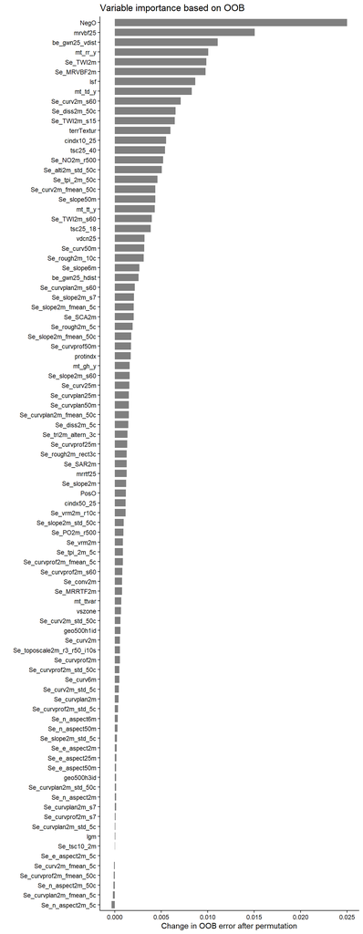

Variable importance based on OBB

```r
# plot variable importance, ordered by decreasing value
gg_wl <- vi_rf_basic_wl |>
  ggplot2::ggplot(ggplot2::aes(x = reorder(variable, value), y = value)) +
  ggplot2::geom_bar(stat = "identity", fill = "grey50", width = 0.75) +
  ggplot2::labs(
    y = "Change in OOB error after permutation",
    x = "",
    title = "Variable importance based on OOB") +
  ggplot2::theme_classic() +
  ggplot2::coord_flip()
gg_wl # display plot
```

dazuschreiben was man sieht, also dass welche variablen die wichtigsten sind -> das hier ist variable importance, danach kommt dann boruta selection

### 2.2.2. Boruta variable selection

```r
# Boruta variable selection
set.seed(42)

# run the algorithm
bor_wl <- Boruta::Boruta(
  y = df_train_wl[, target_wl],
  x = df_train_wl[, predictors_all],
  maxRuns = 50, # Number of iterations. Set to 30 or lower if it takes too long
  num.threads = parallel::detectCores()-1)
```

```r
# obtain results: a data frame with all variables, ordered by their importance
df_bor_wl <- Boruta::attStats(bor_wl) |>
  tibble::rownames_to_column() |>
  dplyr::arrange(dplyr::desc(meanImp))
```

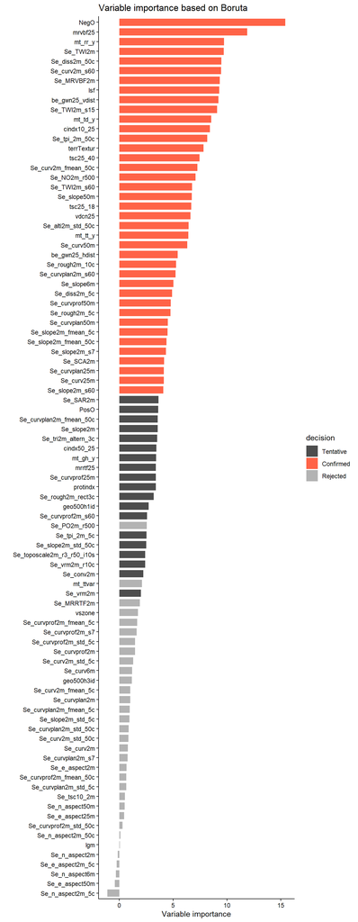

Boruta variable selection

```r
# plot the importance result
ggplot2::ggplot(ggplot2::aes(x = reorder(rowname, meanImp),
                             y = meanImp,
                             fill = decision),
                data = df_bor_wl) +
  ggplot2::geom_bar(stat = "identity", width = 0.75) +
  ggplot2::scale_fill_manual(values = c("grey30", "tomato", "grey70")) +
  ggplot2::labs(
    y = "Variable importance",
    x = "",
    title = "Variable importance based on Boruta") +
  ggplot2::theme_classic() +
  ggplot2::coord_flip()
```

```r
# get retained important variables
predictors_selected_wl <- df_bor_wl |>
  dplyr::filter(decision == "Confirmed") |>
  dplyr::pull(rowname)

length(predictors_selected_wl)
```

```
## [1] 39
```

–> 39 variablen wurden selected, das sind die rot markierten in dem plot obendrüber–> Interpretationstext schreiben welche Variablen ich nehme und wieso (siehe Variablenliste AGDS Buch, was diese bedeuten). von variable importance von davor wurden jetzt welche ausgewählt anhand von Boruta

```r
# re-train Random Forest model with the 39 selected predictors
rf_bor_wl <- ranger::ranger(
  y = df_train_wl[, target_wl],              # target variable
  x = df_train_wl[, predictors_selected_wl], # Predictor variables
  seed = 42,                           # Specify the seed for randomization to reproduce the same model again
  num.threads = parallel::detectCores() - 1)
```

```r
# quick report and performance of trained model object
rf_bor_wl
```

```
## Ranger result
##
## Call:
##  ranger::ranger(y = df_train_wl[, target_wl], x = df_train_wl[,      predictors_selected_wl], seed = 42, num.threads = parallel::detectCores() -      1)
##
## Type:                             Classification
## Number of trees:                  500
## Sample size:                      605
## Number of independent variables:  39
## Mtry:                             6
## Target node size:                 1
## Variable importance mode:         none
## Splitrule:                        gini
## OOB prediction error:             20.00 %
```

Der Out-of-Bag (OOB) Prediction Error ist eine interne Schätzung der Fehlklassifikationsrate des Random Forest.

Ein hoher OOB-Fehler = Modell liegt häufiger falsch → schlechter

Ein niedriger OOB-Fehler = Modell liegt seltener falsch → besser